# 2014.11.15 / BlagoevgradConf

## Life in the Cloud

# Life in the Cloud

Историите на системният адмистратор

## Владимир Витков

### 2014.11.15 / BlagoevgradConf

# Кой е пред вас

- Владимир
- Системен Администратор
- Привърженик на FOSS но не и зеалот
- Експериментатор
- Относително приятен човек за разговор*

# Основи

# Що е това Cloud

- Хостинг - изберете си доставчик
- Инфраструктура под наем (IaaS) - Amazon / Rackspace
- Платформа под наем (PaaS) - Engine Yard / Heroku
- Софтуер под наем (SaaS) - Office365 / Pingdom

# Къде и как се използва

- Обработка на данни
- Допълнителен капацитет
- Намаляне на капиталовите разходи

# Предимства и недостатъци

- Там е и е винаги наличен
- Лесно се експериментира
- Няма (голяма) нужда от Системен администратор
- Като супермаркет е
- Забравят се неща
- Свързаността спира
- Дори и в облака се случва да спре тока

# The APP

# Имаме идея

- Единична машина
- Всичко заедно

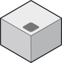

app-idea

# Production Ready

[figure not shown]

Prod Ready

# Production Ready

- Разделяне на компоненти
- Web/App/DB

# Now the traffic comes

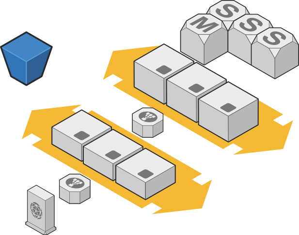

evo

# Now the traffic comes

- Много Frontend-и
- Много Application сървъри
- Master/Slave(s) за базата
- Oh *BEEEP* the traffic keeps comming

# Проблеми и решения

# Прости компоненти

- Тръгват по-бързо
- Искат по-малко ресурси
- По-Лесни са за управление
- По-лесно се търсят грешки в тях

# Прости компоненти (2)

- Зависят един от друг
- Повече неща за управление
- Повече усилие за съвместимост
- Системата става трудна за управление

# Решения

- Опашки
- Твърди API-та
- Developers, Developers, Developers
- Кеширане

# Живот в облака

# DO’s

- Никога не вярвайте на Sales/Marketing
- Бекъпи
- Стратегия за възстановяване (DR)
- Не се заключвайте
- Сървърът не е незаменим

# DO’s (2)

- Дискът може да изчезне*
- Имате си място за игра
- SWAP considered harmfull*
- Test, Test, Test
- Backup, Backup, Backup

# DONT’s

- Не разчитайте до безкрайност
- Сървърите са бетон
- Мрежата е супер ЯКА
- Те си имат няколко захранвания
- Не прекалявайте с дизайна

# DONT’s (2)

- Не забравяйте неизползвани ресурси
- Липсващ мониторинг
- Шумен мониторинг
- Не следете всичко лично
- Не игнорирайте възможностите които имате

# Някои истории

# Аз само рестартирах машината

- Без процедура
- Без инструменти
- На ръка
- Без архиви
- Проста билд машина (лесно)

# Трябва ми бекъпа на dev12

- А правил ли си
- А разчиствал ли си стария
- А казал ли си
- Ама там е всичко
- Админа е малко параноик

# AWS Total Zone failure

- Once upon a time there was AWS eu-west-1a
- It is no more
- Sleep … for someone else
- Let the pain flow trough me

# AWS Power failure

- Инцидент
- 600 VM Dead
- Mass watchdog failure and disconnect
- Аварийно възстановяване на капацитет
- Последващи проблеми с разчистването
- Oh they are phoenixes (with no mind)

# AWS Network Failure

- Хмм нещо прецъка
- 200+ машини изчезнаха
- Този път бяхме подготвени
- 45 мин полуавтоматично възстановяване
- Инфраструкрурни промени

# Blizzard Planning failure

- 1 Mil players in 1 yer
- Nope - 3 months
- Reactive panic mode
- Large scale production refactoring

# Parse 12 mil CV

- Комерсиален Продукт
- Perl/XML/C
- Heavy as shit
- Пусни повече … Затлачване
- Автоматизирано скалиране
- Profit

# Кракване на пароли

- g1/i1/hi1
- Клъстер
- Почти без пари
- Elcomsoft
- WPA Cracking

# Правене на пакети

- As easy as a pie*
- Процедури
- Автоматизация
- wanna-build/buildd
- Clean Room
- Култура

# Тестове/Компилиране

- Cloud is nice
- 10 машини ще направят тестовете по-бързо
- Jenkins/Hudson master + on demand slaves
- Dev is happy
- Accounting is happy
- There are no builders (Yeah price is too high)

# Благодарности и ресурси

# Благодарности

- AWS
- Nik
- Employers
- Линукс За българи
- It-Tour / Яна / Крокодила
- Някой който със сигурност съм забравил

# Връзки

- https://github.com/zeridon/presentations/life-in-the-cloud
- http://www.linux-bg.org
- http://goo.gl/A6m8OC
- https://aws.amazon.com/message/2329B7/
- http://youtu.be/xyPzTywUBsQ